# Projet Stat et R

Choukroun Julien - Gourdon Jessica - Sagnes Luc

## Charger les packages

Dans ce projet, nous allons explorer les données en utilisant le package `dplyr` et visualiser cela en utilisant le package `ggplot2` pour visualiser les données. Les données peuvent être trouvées dans la package `statsr`.

```r
library(dplyr)
library(ggplot2)
library(statsr)
```

## Les données

```r
WorldFactBook <- read.csv(file="WorldFactBook.csv")
dim(WorldFactBook)
```

```
## [1] 279  76
```

## Régression linéaire

L’équation de la droite de régression est obtenue par la méthode des moindres carrés qui calcule les valeurs $\hat{a}$ et $\hat{b}$ de a et b tel que :
$$\hat{a} = \frac{Cov(x,y)}{Var(x)} = \frac{\sum_i (x_i-\bar{x})(y_i-\bar{y})}{\sum_i (x_i-\bar{x})^2}$$
et
$$\hat{b} = \bar{y}-\hat{a}\bar{x} = \frac{1}{n}\sum_i y_i - \hat{a}\sum_i x_i$$
Grâce à la droite de régression linéaire, il est possible de prévoir une tendance pour une valeur donnée x. De plus, l’outil calcule le coefficient de corrélation selon :
$$Corr(x,y) = \frac{Cov(x,y)}{\sigma_x \sigma_y}$$
$$r = (Corr(x,y))^2$$
où $\sigma$ est l’écart type.

Le coefficient de corrélation que l’on note r varie entre -1 et +1. Plus sa valeur absolue est proche de 1, plus le modèle linéaire est fiable et décrit correctement la réalité.

## 1ère étude : Le taux de naissance est-il en corrélation avec le taux de croissance de la population ?

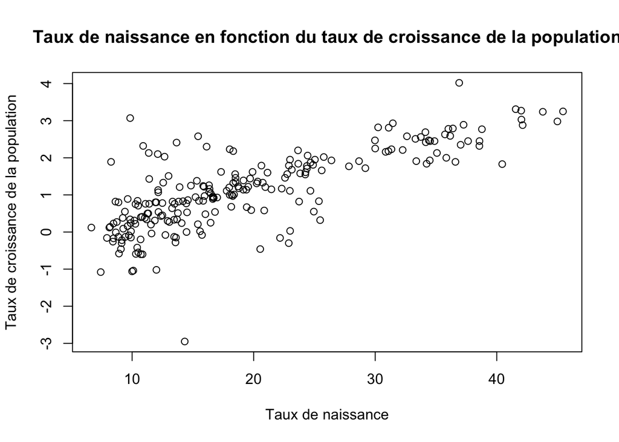

```r
plot(WorldFactBook$Birth.rate, WorldFactBook$Population.growth.rate, main="Taux de naissance en fonction du taux de croissance de la population", xlab="Taux de naissance", ylab="Taux de croissance de la population")
```

On peut voir que le nuage de point suit assez bien une droite croissante.

On va donc calculer les coefficients a et b.

```r
plot(WorldFactBook$Birth.rate, WorldFactBook$Population.growth.rate, main="Corrélation entre le taux de naissance et le taux de croissance de la population", xlab="Taux de naissance", ylab="Taux de croissance de la population")

n = 279 # Nombres de variables trouvé avec dim(World_FactBook).

# Calcul des coefficients a et b.
a = cov(WorldFactBook$Birth.rate, WorldFactBook$Population.growth.rate, use="na.or.complete")/var(WorldFactBook$Birth.rate, na.rm=TRUE)
b = (1/n)*sum(WorldFactBook$Population.growth.rate, na.rm=TRUE) - a*(1/n)*sum(WorldFactBook$Birth.rate, na.rm=TRUE)
paste("Coefficient a : ", a)
```

```
## [1] "Coefficient a :  0.0845161696097913"
```

```r
paste("Coefficient b : ", b)
```

```
## [1] "Coefficient b :  -0.413525225594844"
```

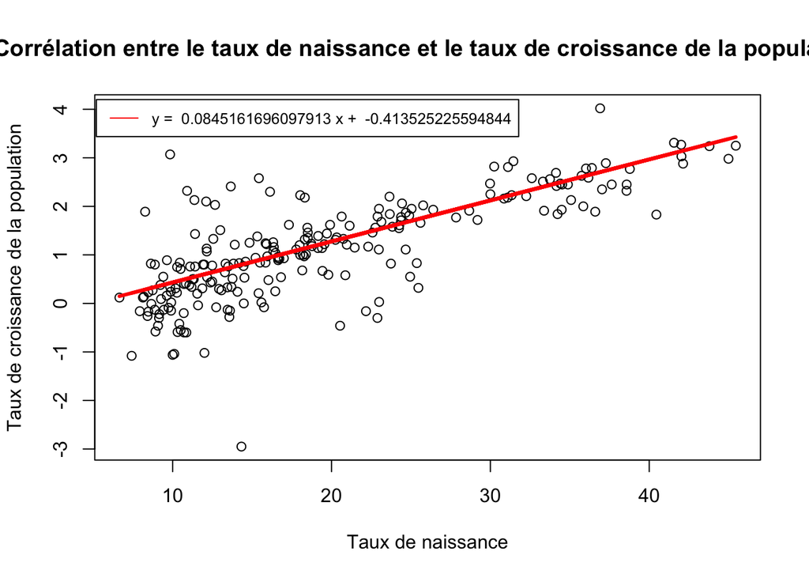

```r
# Equation de la droite.
y = a*WorldFactBook$Birth.rate+b

# Ajout de la droite de régression au graphique.
lines(y~WorldFactBook$Birth.rate, type='l',col='red', lwd=3)
leg = paste("y = ", a, "x + ", b)
legend(5.2,4.2,leg,col='red', lty=1,cex = 0.8)
```

```r
# Calcul de la corrélation.
correlation = cov(WorldFactBook$Birth.rate, WorldFactBook$Population.growth.rate, use="na.or.complete")/(sd(WorldFactBook$Birth.rate, na.rm=TRUE)*sd(WorldFactBook$Population.growth.rate, na.rm=TRUE))
# Calcul du coefficient de corrélation linéaire.
coefficient = correlation^2
paste("Corrélation :", correlation)
```

```
## [1] "Corrélation : 0.764999945532196"
```

```r
paste("Coefficient de corrélation linéaire : ", coefficient)
```

```
## [1] "Coefficient de corrélation linéaire :  0.585224916664262"
```

**Nous vérifions nos caluls avec les formules prédéfinies de R :**

```r
summary(lm(WorldFactBook$Population.growth.rate ~ WorldFactBook$Birth.rate, data = WorldFactBook))
```

```
##
## Call:
## lm(formula = WorldFactBook$Population.growth.rate ~ WorldFactBook$Birth.rate,
##     data = WorldFactBook)
##
## Residuals:
##     Min      1Q  Median      3Q     Max
## -3.6413 -0.3130  0.0424  0.2945  2.7582
##
## Coefficients:
##                           Estimate Std. Error t value Pr(>|t|)
## (Intercept)              -0.519793   0.103311  -5.031    1e-06 ***
## WorldFactBook$Birth.rate  0.084516   0.004777  17.692   <2e-16 ***
## ---
## Signif. codes:  0 '***' 0.001 '**' 0.01 '*' 0.05 '.' 0.1 ' ' 1
##
## Residual standard error: 0.6782 on 222 degrees of freedom
##   (55 observations deleted due to missingness)
## Multiple R-squared:  0.585,  Adjusted R-squared:  0.5832
## F-statistic:   313 on 1 and 222 DF,  p-value: < 2.2e-16
```

Nous observons que nos valeurs calculatoires sont assez proches des valeurs calculées par la fonction R.

Maintenant, nous calculons l’intervalle de confiance grâce à :
$$\bar{x} \pm z^\star \frac{\sigma}{\sqrt{n}}$$
où $z^\star$ est la valeur critique à droite, $\sigma$ est l’écart type et $\bar{x}$ est la moyenne.

```r
plot(WorldFactBook$Birth.rate, WorldFactBook$Population.growth.rate, main="Corrélation entre le taux de naissance et le taux de croissance de la population", xlab="Taux de naissance", ylab="Taux de croissance de la population")
lines(y~WorldFactBook$Birth.rate, type='l',col='red', lwd=3)
leg = paste("y = ", a, "x + ", b)
legend(5.2,4.2,leg,col='red', lty=1,cex = 0.8)

# On calcule la valeur critique pour un intervalle de confiance de 95%.
z_star_95 <- qnorm(0.975)
paste("Valeur critique pour un intervalle de confiance de 95% : ", z_star_95)
```

```
## [1] "Valeur critique pour un intervalle de confiance de 95% :  1.95996398454005"
```

```r
# Calcul des intervalles :
inf = mean(WorldFactBook$Birth.rate, na.rm=TRUE) - z_star_95 * (sd(WorldFactBook$Birth.rate, na.rm=TRUE) / sqrt(n))
sup = mean(WorldFactBook$Birth.rate, na.rm=TRUE) + z_star_95 * (sd(WorldFactBook$Birth.rate, na.rm=TRUE) / sqrt(n))
paste("Valeur minimale : ", inf)
```

```
## [1] "Valeur minimale :  18.3194236178005"
```

```r
paste("Valeur maximale : ", sup)
```

```
## [1] "Valeur maximale :  20.5503085250567"
```

```r
# L'erreur :
erreur = (sup-inf)/2
paste("Erreur : ", erreur)
```

```
## [1] "Erreur :  1.11544245362809"
```

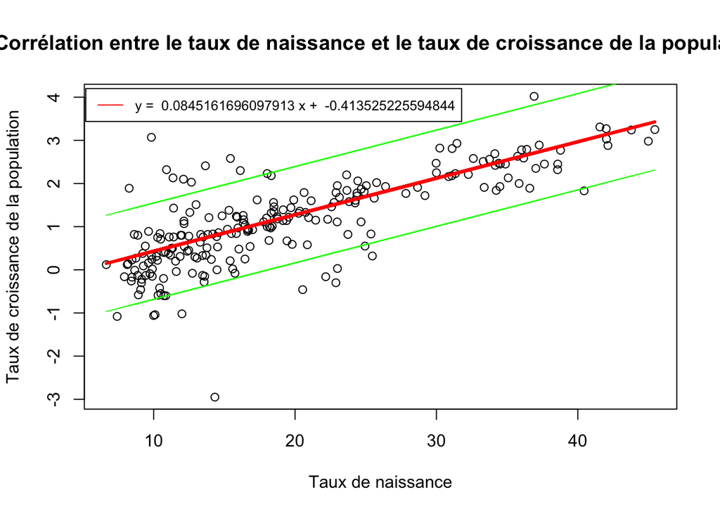

```r
# Nos 2 droites d'intervalle de confiance.
y_sup = y+erreur
y_inf = y-erreur
# Ajout des droites d'intervalle de confiance au graphique.
lines(y_sup~WorldFactBook$Birth.rate, type='l',col='green')
lines(y_inf~WorldFactBook$Birth.rate, type='l',col='green')
```

**Conclusion de la 1ère étude** Nous avons un coefficient pour la droite de régression qui est d’environ 0.6. Cela nous permet de dire que la qualité de la regression est assez bonne. Nous pouvons également dire, grâce au graphe de la droite que le taux de naissance est assez corrélé avec le taux de croissance de la population (pente non nulle de la droite).

## 2ème étude : Le PIB par habitant est-il en corrélation avec le taux de naissance ?

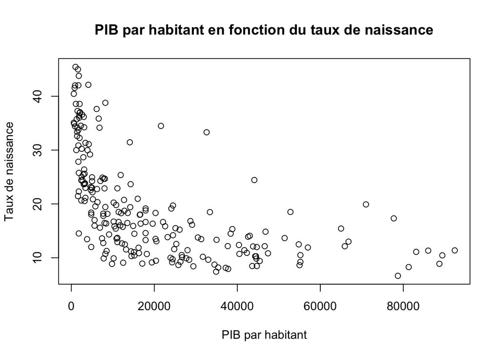

```r
plot(WorldFactBook$GDP...per.capita..PPP., WorldFactBook$Birth.rate, main="PIB par habitant en fonction du taux de naissance", xlab="PIB par habitant", ylab="Taux de naissance")
```

On va donc calculer les coefficients a et b.

```r
plot(WorldFactBook$GDP...per.capita..PPP., WorldFactBook$Birth.rate, main="Corrélation entre le PIB par habitant et le taux de naissance", xlab="PIB par habitant", ylab="Taux de naissance")

n = 279 # Nombres de variables trouvé avec dim(World_FactBook).

# Calcul des coefficients a et b.
a = cov(WorldFactBook$GDP...per.capita..PPP., WorldFactBook$Birth.rate, use="na.or.complete")/var(WorldFactBook$GDP...per.capita..PPP., na.rm=TRUE)
b = (1/n)*sum(WorldFactBook$Birth.rate, na.rm=TRUE) - a*(1/n)*sum(WorldFactBook$GDP...per.capita..PPP., na.rm=TRUE)
paste("Coefficient a : ", a)
```

```
## [1] "Coefficient a :  -0.000265982106435941"
```

```r
paste("Coefficient b : ", b)
```

```
## [1] "Coefficient b :  19.8950840577828"
```

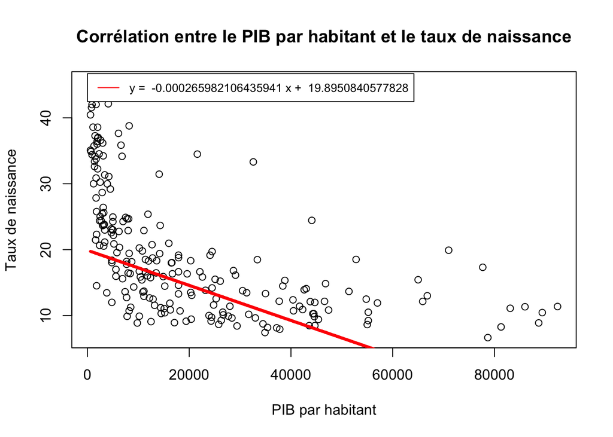

```r
# Equation de la droite.
y = a*WorldFactBook$GDP...per.capita..PPP.+b

# Ajout de la droite de régression au graphique.
lines(y~WorldFactBook$GDP...per.capita..PPP., type='l',col='red', lwd=3)
leg = paste("y = ", a, "x + ", b)
legend(0,46.7,leg,col='red', lty=1,cex = 0.8)
```

```r
# Calcul de la corrélation.
correlation = cov(WorldFactBook$GDP...per.capita..PPP., WorldFactBook$Birth.rate, use="na.or.complete")/(sd(WorldFactBook$GDP...per.capita..PPP., na.rm=TRUE)*sd(WorldFactBook$Birth.rate, na.rm=TRUE))
# Calcul du coefficient de corrélation linéaire.
coefficient = correlation^2
paste("Corrélation :", correlation)
```

```
## [1] "Corrélation : -0.569060189670853"
```

```r
paste("Coefficient de corrélation linéaire : ", coefficient)
```

```
## [1] "Coefficient de corrélation linéaire :  0.323829499468227"
```

**Nous vérifions nos caluls avec les formules prédéfinies de R :**

```r
summary(lm(WorldFactBook$Birth.rate ~ WorldFactBook$GDP...per.capita..PPP., data = WorldFactBook))
```

```
##
## Call:
## lm(formula = WorldFactBook$Birth.rate ~ WorldFactBook$GDP...per.capita..PPP.,
##     data = WorldFactBook)
##
## Residuals:
##     Min      1Q  Median      3Q     Max
## -13.202  -6.010  -1.553   4.543  21.050
##
## Coefficients:
##                                        Estimate Std. Error t value Pr(>|t|)
## (Intercept)                           2.466e+01  7.335e-01   33.63   <2e-16 ***
## WorldFactBook$GDP...per.capita..PPP. -2.645e-04  2.583e-05  -10.24   <2e-16 ***
## ---
## Signif. codes:  0 '***' 0.001 '**' 0.01 '*' 0.05 '.' 0.1 ' ' 1
##
## Residual standard error: 7.831 on 220 degrees of freedom
##   (57 observations deleted due to missingness)
## Multiple R-squared:  0.3228, Adjusted R-squared:  0.3197
## F-statistic: 104.9 on 1 and 220 DF,  p-value: < 2.2e-16
```

Nous observons que nos valeurs calculatoires sont assez proches des valeurs calculées par la fonction R.

Maintenant, nous calculons l’intervalle de confiance grâce à :
$$\bar{x} \pm z^\star \frac{\sigma}{\sqrt{n}}$$
où $z^\star$ est la valeur critique à droite, $\sigma$ est l’écart type et $\bar{x}$ est la moyenne.

```r
plot(WorldFactBook$GDP...per.capita..PPP., WorldFactBook$Birth.rate, main="Corrélation entre le PIB par habitant et le taux de naissance", xlab="PIB par habitant", ylab="Taux de naissance")
lines(y~WorldFactBook$GDP...per.capita..PPP., type='l',col='red', lwd=3)
leg = paste("y = ", a, "x + ", b)
legend(0,46.7,leg,col='red', lty=1,cex = 0.8)

# On calcule la valeur critique pour un intervalle de confiance de 95%.
z_star_95 <- qnorm(0.975)
paste("Valeur critique pour un intervalle de confiance de 95% : ", z_star_95)
```

```
## [1] "Valeur critique pour un intervalle de confiance de 95% :  1.95996398454005"
```

```r
# Calcul des intervalles :
inf = mean(WorldFactBook$GDP...per.capita..PPP., na.rm=TRUE) - z_star_95 * (sd(WorldFactBook$GDP...per.capita..PPP., na.rm=TRUE) / sqrt(n))
sup = mean(WorldFactBook$GDP...per.capita..PPP., na.rm=TRUE) + z_star_95 * (sd(WorldFactBook$GDP...per.capita..PPP., na.rm=TRUE) / sqrt(n))
paste("Valeur minimale : ", inf)
```

```
## [1] "Valeur minimale :  17356.967682764"
```

```r
paste("Valeur maximale : ", sup)
```

```
## [1] "Valeur maximale :  22129.8744224991"
```

```r
# L'erreur :
erreur = (sup-inf)/2
paste("Erreur : ", erreur)
```

```
## [1] "Erreur :  2386.45336986757"
```

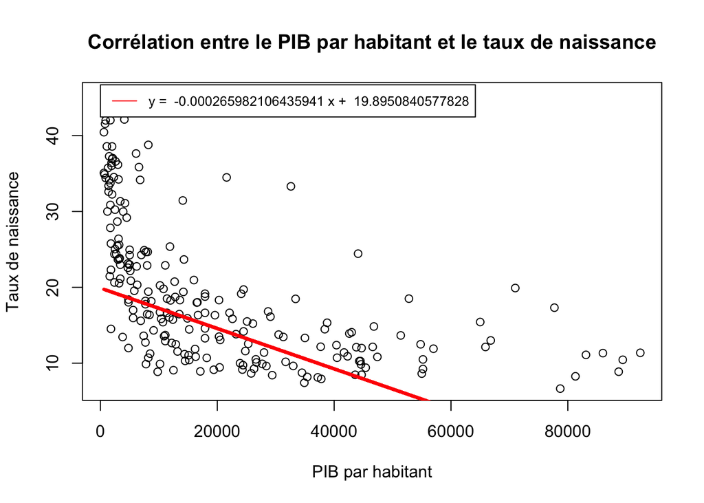

```r
# Nos 2 droites d'intervalle de confiance.
y_sup = y+erreur
y_inf = y-erreur
# Ajout des droites d'intervalle de confiance au graphique.
lines(y_sup~WorldFactBook$GDP...per.capita..PPP., type='l',col='green')
lines(y_inf~WorldFactBook$GDP...per.capita..PPP., type='l',col='green')
```

## 3ème étude : Les dépenses dans l’éducation sont-elle en corrélation avec les dépenses dans la santé ?

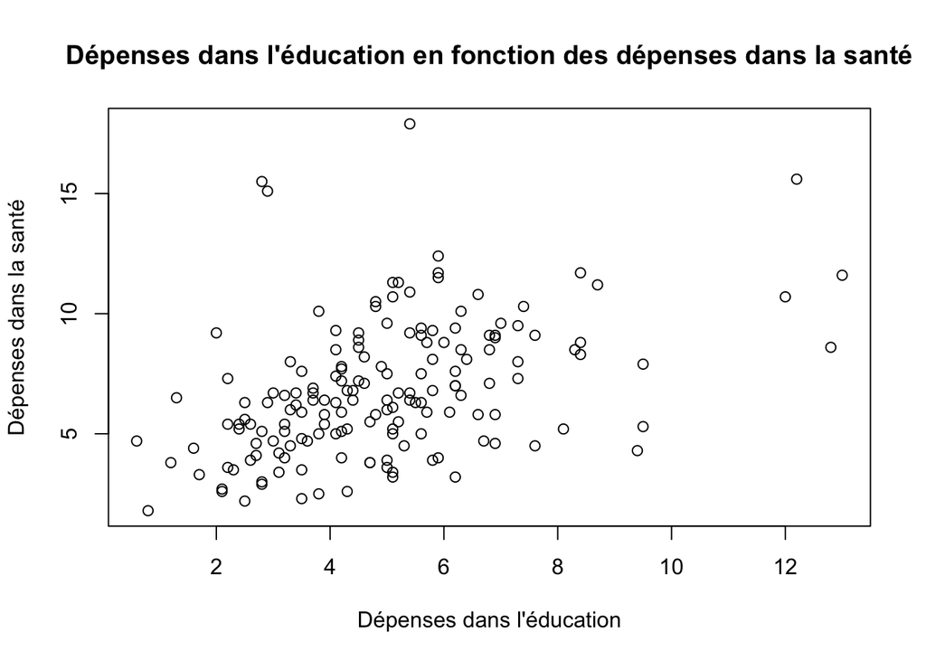

```r
plot(WorldFactBook$Education.expenditures, WorldFactBook$Health.expenditures, main="Dépenses dans l'éducation en fonction des dépenses dans la santé", xlab="Dépenses dans l'éducation", ylab="Dépenses dans la santé")
```

On va donc calculer les coefficients a et b.

```r
plot(WorldFactBook$Education.expenditures, WorldFactBook$Health.expenditures, main="Corrélation entre les dépenses dans l'éducation et les dépenses dans la santé", xlab="Dépenses dans l'éducation", ylab="Dépenses dans la santé")

n = 279 # Nombres de variables trouvé avec dim(World_FactBook).

# Calcul des coefficients a et b.
a = cov(WorldFactBook$Education.expenditures, WorldFactBook$Health.expenditures, use="na.or.complete")/var(WorldFactBook$Education.expenditures, na.rm=TRUE)
b = (1/n)*sum(WorldFactBook$Health.expenditures, na.rm=TRUE) - a*(1/n)*sum(WorldFactBook$Education.expenditures, na.rm=TRUE)
paste("Coefficient a : ", a)
```

```
## [1] "Coefficient a :  0.573576974613196"
```

```r
paste("Coefficient b : ", b)
```

```
## [1] "Coefficient b :  2.95431074918415"
```

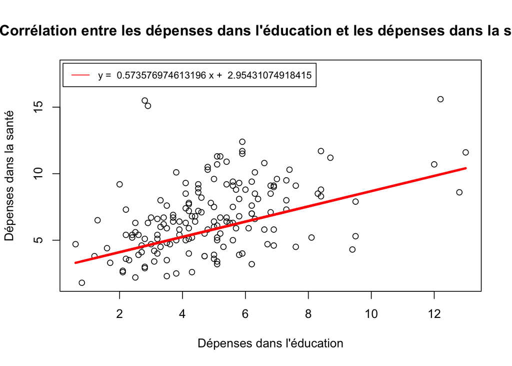

```r
# Equation de la droite.
y = a*WorldFactBook$Education.expenditures+b

# Ajout de la droite de régression au graphique.
lines(y~WorldFactBook$Education.expenditures, type='l',col='red', lwd=3)
leg = paste("y = ", a, "x + ", b)
legend(0.2,18.3,leg,col='red', lty=1,cex = 0.8)
```

```r
# Calcul de la corrélation.
correlation = cov(WorldFactBook$Education.expenditures, WorldFactBook$Health.expenditures, use="na.or.complete")/(sd(WorldFactBook$Education.expenditures, na.rm=TRUE)*sd(WorldFactBook$Health.expenditures, na.rm=TRUE))
# Calcul du coefficient de corrélation linéaire.
coefficient = correlation^2
paste("Corrélation :", correlation)
```

```
## [1] "Corrélation : 0.435985502108538"
```

```r
paste("Coefficient de corrélation linéaire : ", coefficient)
```

```
## [1] "Coefficient de corrélation linéaire :  0.190083358048834"
```

**Nous vérifions nos caluls avec les formules prédéfinies de R :**

```r
summary(lm(WorldFactBook$Health.expenditures ~ WorldFactBook$Education.expenditures, data = WorldFactBook))
```

```
##
## Call:
## lm(formula = WorldFactBook$Health.expenditures ~ WorldFactBook$Education.expenditures,
##     data = WorldFactBook)
##
## Residuals:
##     Min      1Q  Median      3Q     Max
## -5.0792 -1.5545 -0.1708  1.2768 10.7861
##
## Coefficients:
##                                      Estimate Std. Error t value Pr(>|t|)
## (Intercept)                           4.05574    0.49369   8.215 6.39e-14 ***
## WorldFactBook$Education.expenditures  0.56633    0.09175   6.173 5.19e-09 ***
## ---
## Signif. codes:  0 '***' 0.001 '**' 0.01 '*' 0.05 '.' 0.1 ' ' 1
##
## Residual standard error: 2.526 on 162 degrees of freedom
##   (115 observations deleted due to missingness)
## Multiple R-squared:  0.1904, Adjusted R-squared:  0.1854
## F-statistic:  38.1 on 1 and 162 DF,  p-value: 5.19e-09
```

Nous observons que nos valeurs calculatoires sont assez proches des valeurs calculées par la fonction R.

Maintenant, nous calculons l’intervalle de confiance grâce à :
$$\bar{x} \pm z^\star \frac{\sigma}{\sqrt{n}}$$
où $z^\star$ est la valeur critique à droite, $\sigma$ est l’écart type et $\bar{x}$ est la moyenne.

```r
plot(WorldFactBook$Education.expenditures, WorldFactBook$Health.expenditures, main="Corrélation entre les dépenses dans l'éducation et les dépenses dans la santé", xlab="Dépenses dans l'éducation", ylab="Dépenses dans la santé")
lines(y~WorldFactBook$Education.expenditures, type='l',col='red', lwd=3)
leg = paste("y = ", a, "x + ", b)
legend(0.2,18.3,leg,col='red', lty=1,cex = 0.8)

# On calcule la valeur critique pour un intervalle de confiance de 95%.
z_star_95 <- qnorm(0.975)
paste("Valeur critique pour un intervalle de confiance de 95% : ", z_star_95)
```

```
## [1] "Valeur critique pour un intervalle de confiance de 95% :  1.95996398454005"
```

```r
# Calcul des intervalles :
inf = mean(WorldFactBook$Education.expenditures, na.rm=TRUE) - z_star_95 * (sd(WorldFactBook$Education.expenditures, na.rm=TRUE) / sqrt(n))
sup = mean(WorldFactBook$Education.expenditures, na.rm=TRUE) + z_star_95 * (sd(WorldFactBook$Education.expenditures, na.rm=TRUE) / sqrt(n))
paste("Valeur minimale : ", inf)
```

```
## [1] "Valeur minimale :  4.60346215051129"
```

```r
paste("Valeur maximale : ", sup)
```

```
## [1] "Valeur maximale :  5.10636443908409"
```

```r
# L'erreur :
erreur = (sup-inf)/2
paste("Erreur : ", erreur)
```

```
## [1] "Erreur :  0.251451144286402"
```

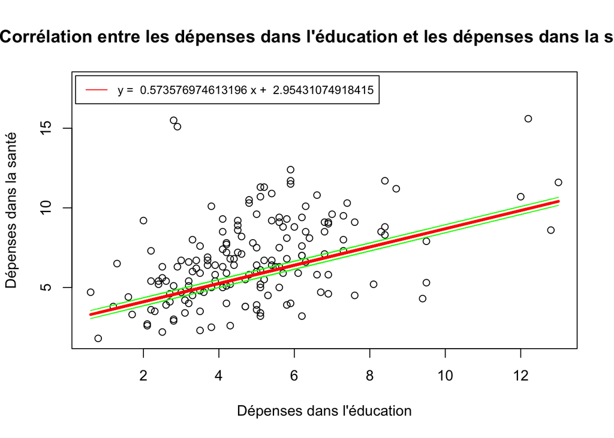

```r
# Nos 2 droites d'intervalle de confiance.
y_sup = y+erreur
y_inf = y-erreur
# Ajout des droites d'intervalle de confiance au graphique.
lines(y_sup~WorldFactBook$Education.expenditures, type='l',col='green')
lines(y_inf~WorldFactBook$Education.expenditures, type='l',col='green')
```

## 4ème étude : La consommation d’électricité est-elle en corrélation avec le PIB ?

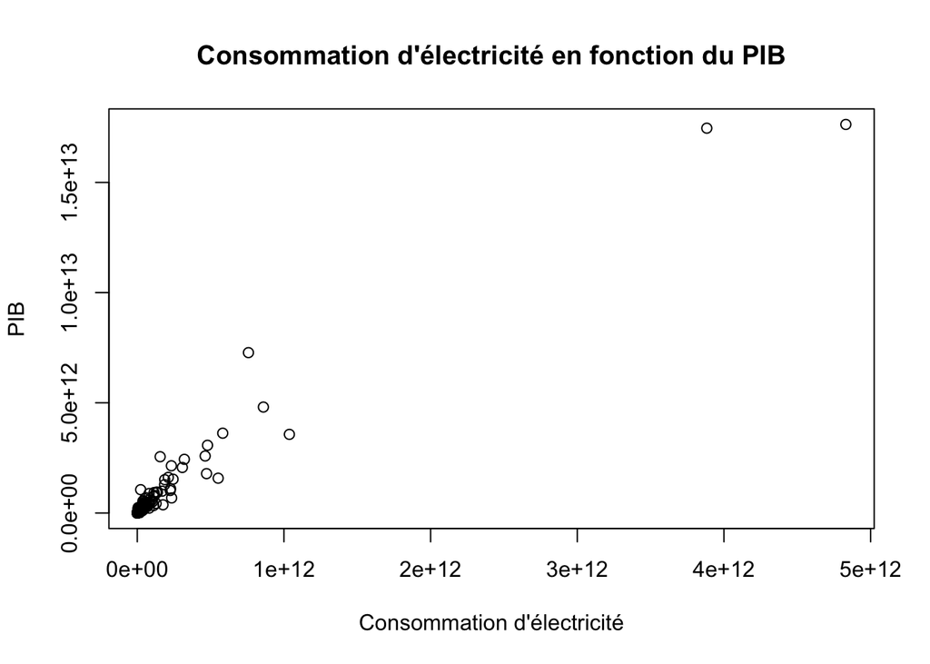

```r
plot(WorldFactBook$Electricity...consumption, WorldFactBook$GDP..purchasing.power.parity., main="Consommation d'électricité en fonction du PIB", xlab="Consommation d'électricité", ylab="PIB")
```

On peut voir que le nuage de point suit assez bien une droite croissante.

On va donc calculer les coefficients a et b.

```r
plot(WorldFactBook$Electricity...consumption, WorldFactBook$GDP..purchasing.power.parity., main="Corrélation entre la consommation d'électricité et le PIB", xlab="Consommation d'électricité", ylab="PIB")

n = 279 # Nombres de variables trouvé avec dim(World_FactBook).

# Calcul des coefficients a et b.
a = cov(WorldFactBook$Electricity...consumption, WorldFactBook$GDP..purchasing.power.parity., use="na.or.complete")/var(WorldFactBook$Electricity...consumption, na.rm=TRUE)
b = (1/n)*sum(WorldFactBook$GDP..purchasing.power.parity., na.rm=TRUE) - a*(1/n)*sum(WorldFactBook$Electricity...consumption, na.rm=TRUE)
paste("Coefficient a : ", a)
```

```
## [1] "Coefficient a :  4.11951507992562"
```

```r
paste("Coefficient b : ", b)
```

```
## [1] "Coefficient b :  87864801413.3076"
```

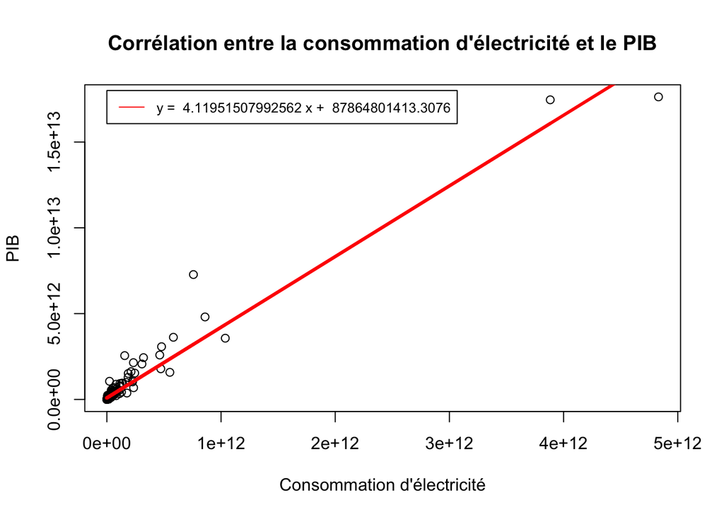

```r
# Equation de la droite.
y = a*WorldFactBook$Electricity...consumption+b

# Ajout de la droite de régression au graphique.
lines(y~WorldFactBook$Electricity...consumption, type='l',col='red', lwd=3)
leg = paste("y = ", a, "x + ", b)
legend(0,1.8e+13,leg,col='red', lty=1,cex = 0.8)
```

```r
# Calcul de la corrélation.
correlation = cov(WorldFactBook$Electricity...consumption, WorldFactBook$GDP..purchasing.power.parity., use="na.or.complete")/(sd(WorldFactBook$Electricity...consumption, na.rm=TRUE)*sd(WorldFactBook$GDP..purchasing.power.parity., na.rm=TRUE))
# Calcul du coefficient de corrélation linéaire.
coefficient = correlation^2
paste("Corrélation :", correlation)
```

```
## [1] "Corrélation : 0.999239278137855"
```

```r
paste("Coefficient de corrélation linéaire : ", coefficient)
```

```
## [1] "Coefficient de corrélation linéaire :  0.998479134973461"
```

**Nous vérifions nos caluls avec les formules prédéfinies de R :**

```r
summary(lm(WorldFactBook$GDP..purchasing.power.parity. ~ WorldFactBook$Electricity...consumption, data = WorldFactBook))
```

```
##
## Call:
## lm(formula = WorldFactBook$GDP..purchasing.power.parity. ~ WorldFactBook$Electricity...consumption,
##     data = WorldFactBook)
##
## Residuals:
##        Min         1Q     Median         3Q        Max
## -2.298e+12 -1.140e+11 -1.015e+11 -2.314e+10  4.054e+12
##
## Coefficients:
##                                          Estimate Std. Error t value Pr(>|t|)
## (Intercept)                             1.146e+11  2.994e+10   3.826 0.000171
## WorldFactBook$Electricity...consumption 4.101e+00  6.726e-02  60.974  < 2e-16
##
## (Intercept)                             ***
## WorldFactBook$Electricity...consumption ***
## ---
## Signif. codes:  0 '***' 0.001 '**' 0.01 '*' 0.05 '.' 0.1 ' ' 1
##
## Residual standard error: 4.314e+11 on 215 degrees of freedom
##   (62 observations deleted due to missingness)
## Multiple R-squared:  0.9453, Adjusted R-squared:  0.9451
## F-statistic:  3718 on 1 and 215 DF,  p-value: < 2.2e-16
```

Maintenant, nous calculons l’intervalle de confiance grâce à :
$$\bar{x} \pm z^\star \frac{\sigma}{\sqrt{n}}$$
où $z^\star$ est la valeur critique à droite, $\sigma$ est l’écart type et $\bar{x}$ est la moyenne.

```r
plot(WorldFactBook$Electricity...consumption, WorldFactBook$GDP..purchasing.power.parity., main="Corrélation entre la consommation d'électricité et le PIB", xlab="Consommation d'électricité", ylab="PIB")
lines(y~WorldFactBook$Electricity...consumption, type='l',col='red', lwd=3)
leg = paste("y = ", a, "x + ", b)
legend(0,1.8e+13,leg,col='red', lty=1,cex = 0.8)

# On calcule la valeur critique pour un intervalle de confiance de 95%.
z_star_95 <- qnorm(0.975)
paste("Valeur critique pour un intervalle de confiance de 95% : ", z_star_95)
```

```
## [1] "Valeur critique pour un intervalle de confiance de 95% :  1.95996398454005"
```

```r
# Calcul des intervalles :
inf = mean(WorldFactBook$Electricity...consumption, na.rm=TRUE) - z_star_95 * (sd(WorldFactBook$Electricity...consumption, na.rm=TRUE) / sqrt(n))
sup = mean(WorldFactBook$Electricity...consumption, na.rm=TRUE) + z_star_95 * (sd(WorldFactBook$Electricity...consumption, na.rm=TRUE) / sqrt(n))
paste("Valeur minimale : ", inf)
```

```
## [1] "Valeur minimale :  41356832965.4656"
```

```r
paste("Valeur maximale : ", sup)
```

```
## [1] "Valeur maximale :  143540531165.727"
```

```r
# L'erreur :
erreur = (sup-inf)/2
paste("Erreur : ", erreur)
```

```
## [1] "Erreur :  51091849100.1307"
```

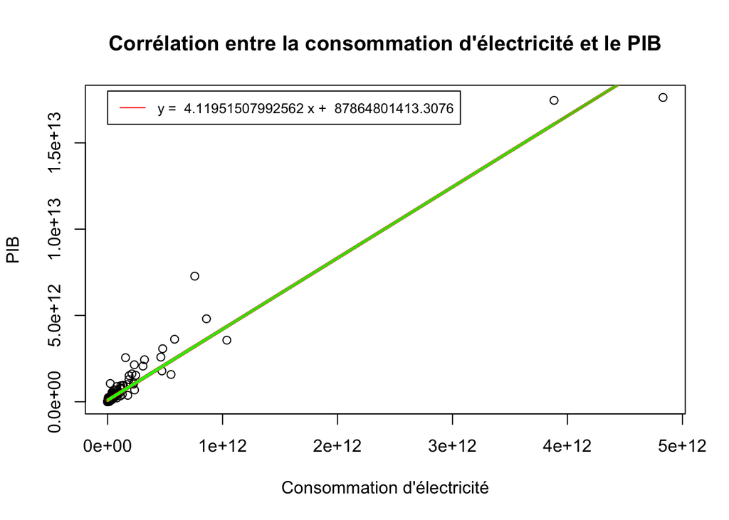

```r
# Nos 2 droites d'intervalle de confiance.
y_sup = y+erreur
y_inf = y-erreur
# Ajout des droites d'intervalle de confiance au graphique.
lines(y_sup~WorldFactBook$Electricity...consumption, type='l',col='green')
lines(y_inf~WorldFactBook$Electricity...consumption, type='l',col='green')
```

**Conclusion de la 4ème étude** Nous avons un coefficient pour la droite de régression qui est d’environ 0.99. Cela nous permet de dire que la qualité de la regression est très bonne. Nous pouvons également dire, grâce au graphe de la droite que la consommation d’électricité est très corrélée avec le PIB (pente non nulle de la droite).